```python
import pylab as pl
from  numpy.random import normal
import numpy as np
import healpy as hp
from scipy  import  signal
from scipy.signal import periodogram

from pylab import cm
cmap = cm.get_cmap('RdYlBu')
cmap.set_under('w')
import scipy.stats as spt
from scipy import interpolate

folder = '/Users/peppe/work/satellite_sims/'
%matplotlib inline
fs=20
```

```python
from IPython.display import HTML

HTML('''<script>
code_show=true;
function code_toggle() {
 if (code_show){
 $('div.input').hide();
 } else {
 $('div.input').show();
 }
 code_show = !code_show
}
$( document ).ready(code_toggle);
</script>
<form action="javascript:code_toggle()"><input type="submit" value="Click here to toggle on/off the raw code."></form>''')
```

# 1. Summary

09/02/2019

In [my previous posting](http://giuspugl.github.io/reports/GainDrift_20190809.html), I've presented the parametrization adopted to inject (and mitigate) gain drift systematics.

*In this posting I show that we are able to track $\sim10$ percent gain fluctuations on the time scale of up to 1 minute by regressing the time samples (including noise and sky signal) with CMB Temperature template map.* Moreover, smaller gain fluctuations (order of few per cents) are harder to track because noise affects the estimates, in this case a longer time scale might be helpful .

### Simulation setups

Toast Params ( values from v0 [Litebird-IMO wiki page](https://wiki.kek.jp/pages/viewpage.action?pageId=108104267):

- Detector pairs: 2
- frequency band: 89 GHz
- T_obs : 5 hours
- sampling freq: 20 Hz
- precession period :192.348 min
- spin period: 20 min
- Noise simulated : white
- NET : 30 uK sqrt(s)
- HWP : False
- spin angle : 50
- precession angle :45
- MADAM destriper (baseline=60 sec)
- Input maps: Monopole, Dipole, CMB T , Galactic emission @90 GHz

#### Gain drift sim

Simulate per detector a time stream signal $g(t)$ fluctuating around 1 with a low frequency component with a 1/f dependence $fknee = 150 $ mHz .

Multiply $g$ by the detector TOD.

#### Gain estimation

The procedure to mitigate gain mismatches is performed on each chunck (related to $\tau$) of time samples $d_{t , t+\tau}$ of a given detector:

1. Apply a high-pass filter to $d_{t , t+\tau} $ with cutoff frequency $f_{c}=5$ mHz
2. Regress $d_{t , t+\tau} $ against signal-only template $T$ and estimate the regression slope $\hat{g}$ as $$ \hat{g} = \frac { T^{t} d } { T^{t} T } $$
3. Mitigate the leakage, dividing $d_{t , t+\tau} $ by $\hat{g}$

```python
from scipy.signal import butter, lfilter

def butter_bandpass(lowcut, fs, order=5):
    nyq = 0.5 * fs
    low = lowcut / nyq
    b, a = butter(order, low, btype='highpass')
    return b, a


def butter_bandpass_filter( lowcut,   fs, data, order=5):
    b, a = butter_bandpass(lowcut,  fs, order=order)
    padl  = np.int_( fs/(lowcut))
    y = signal.filtfilt (b, a, data , padlen= padl, padtype='constant')
    return y


def band_pass_filter(fcutoff, fsampl, data, filtermode='high' ):
    alpha=2. *fcutoff  /fsampl
    padlength = np.int_( fsampl/(fcutoff))
    b, a = signal.butter(4, alpha , filtermode)
    pdata=pl.pad(data ,  pad_width =(padlength,padlength  ), mode ='symmetric', reflect_type='odd' )
    filtsignal=  signal.filtfilt(b, a, pdata,  padlen=0 )
    #return filtsignal
    return filtsignal[slice ( padlength ,  -padlength) ]

def bin_gains(tau, fs,obs,  g) :
    sizech = pl.int_( tau *fs)  ; nch =pl.int_(  obs *fs*3600  /sizech)
    gb = pl.zeros(nch)
    for i in range (nch):
        gb[i] =g[slice(i*sizech, (i+1)*sizech)] .mean()
    return gb
```

## 10 per cent gain fluctuations

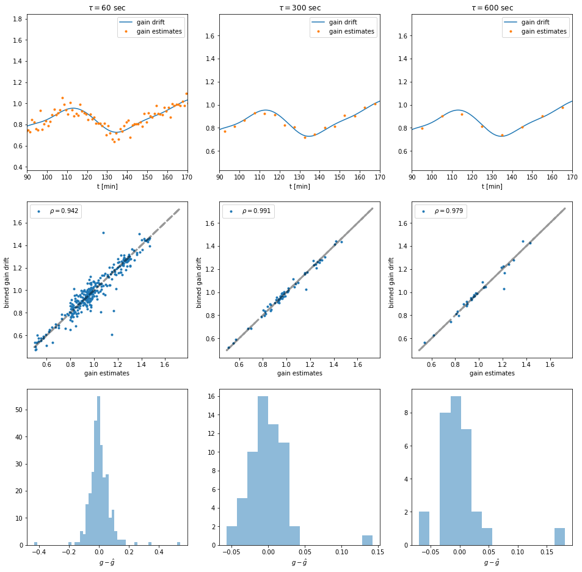

```python
pl.figure(figsize=(16,16))
obs=5.
folder = '/Users/peppe/work/satellite_sims/sigmag_1em2/'

pl.subplot(331)
tau10 =60
pl.title(r'$\tau= {} $ sec'.format(tau10))

fs=20
g=pl.load(folder+ 'gain_drift.npy')
N = len(g[0] )

gb = [ bin_gains(tau10,fs, obs,g[0,:]) , bin_gains(tau10,fs, obs,g[ 1,:] ) ]

ge  = pl.load(folder+'gains_coeff_'+str(tau10)+'.npy')
t=  pl.arange(N)/60. /fs
obs =5.
pl.plot(t,1+ g[1 ], label='gain drift')
#print(ge[1,0,:]/60/ fs)
pl.plot(ge[1,0,:]/ 60/fs
        , ge[1,1,:], '.', label = 'gain estimates')
pl.xlabel('t [min]')
pl.legend()

pl.xlim((90,170))
pl.subplot(337)

_ = pl.hist((1+ gb[0]) -ge[0,1,: ],bins='auto', alpha=.5 )

_=pl.xlabel(r'$g - \hat{g} $')

pl.subplot(334)
r=spt.linregress((1+ gb[0]), ge[0,1,: ])[2]
pl.scatter((1+ gb[0]) ,ge[0,1,: ], marker='.' ,label=r'$\rho = {:.3f}$' .format(r))
pl.plot( (g[1])+1 ,1+ g[1],'--',color='k', alpha=.4, lw=3 )
pl.xlabel('gain estimates')
pl.ylabel('binned gain drift   ')
pl.legend()

pl.subplot(332)
tau10 =300
pl.title(r'$\tau= {} $ sec'.format(tau10))

fs=20
g=pl.load(folder+ 'gain_drift.npy')
N = len(g[0] )

gb = [ bin_gains(tau10,fs, obs,g[0,:]) , bin_gains(tau10,fs, obs,g[ 1,:] ) ]

ge  = pl.load(folder+'gains_coeff_'+str(tau10)+'.npy')
t=  pl.arange(N)/60. /fs
obs =5.
pl.plot(t,1+ g[1 ], label='gain drift')
#print(ge[1,0,:]/60/ fs)
pl.plot(ge[1,0,:]/ 60/fs
        , ge[1,1,:], '.', label = 'gain estimates')
pl.xlabel('t [min]')
pl.legend()
pl.xlim((90,170))
pl.subplot(335)
r=spt.linregress((1+ gb[0]), ge[0,1,: ])[2]
pl.scatter((1+ gb[0]) ,ge[0,1,: ], marker='.' ,label=r'$\rho = {:.3f}$' .format(r))
pl.xlabel('gain estimates')
pl.ylabel('binned gain drift   ')

pl.legend()
pl.plot( (g[1])+1 ,1+ g[1],'--',color='k', alpha=.4, lw=3 )
pl.subplot(338)

_ = pl.hist((1+ gb[0]) -ge[0,1,: ],bins='auto', alpha=.5 )
_=pl.xlabel(r'$g - \hat{g} $')

pl.subplot(333)
tau10 =600
pl.title(r'$\tau= {} $ sec'.format(tau10))

fs=20
g=pl.load(folder+ 'gain_drift.npy')
N = len(g[0] )

gb = [ bin_gains(tau10,fs, obs,g[0,:]) , bin_gains(tau10,fs, obs,g[ 1,:] ) ]

ge  = pl.load(folder+'gains_coeff_'+str(tau10)+'.npy')
t=  pl.arange(N)/60. /fs
obs =5.
pl.plot(t,1+ g[1 ], label='gain drift')
#print(ge[1,0,:]/60/ fs)
pl.plot(ge[1,0,:]/ 60/fs
        , ge[1,1,:], '.', label = 'gain estimates')
pl.xlabel('t [min]')
pl.legend()
pl.xlim((90,170))
pl.subplot(336)
r=spt.linregress((1+ gb[0]), ge[0,1,: ])[2]
pl.scatter((1+ gb[0]) ,ge[0,1,: ], marker='.' ,label=r'$\rho = {:.3f}$' .format(r))
pl.legend()
pl.xlabel('gain estimates')
pl.ylabel('binned gain drift   ')
pl.plot( (g[1])+1 ,1+ g[1],'--',color='k', alpha=.4, lw=3 )

pl.subplot(339)
_ = pl.hist((1+ gb[0]) -ge[0,1,: ],bins='auto', alpha=.5 )
_=pl.xlabel(r'$g - \hat{g} $')
```

## 1 per cent gain fluctuations

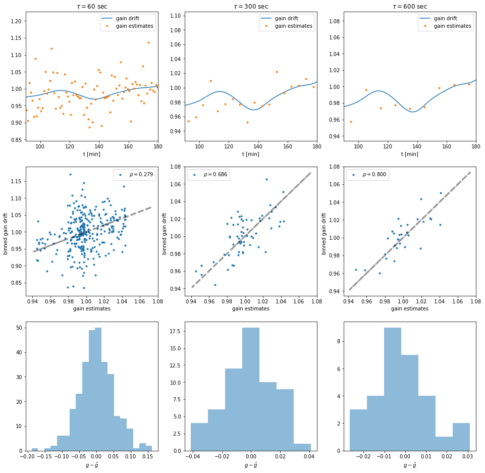

```python
pl.figure(figsize=(16,16))
obs=5.
folder = '/Users/peppe/work/satellite_sims/'

pl.subplot(331)
tau10 =60
pl.title(r'$\tau= {} $ sec'.format(tau10))

fs=20
g=pl.load(folder+ 'gain_drift.npy')
N = len(g[0] )

gb = [ bin_gains(tau10,fs, obs,g[0,:]) , bin_gains(tau10,fs, obs,g[ 1,:] ) ]

ge  = pl.load(folder+'gains_coeff_'+str(tau10)+'.npy')
t=  pl.arange(N)/60. /fs
obs =5.
pl.plot(t,1+ g[1 ], label='gain drift')
#print(ge[1,0,:]/60/ fs)
pl.plot(ge[1,0,:]/ 60/fs
        , ge[1,1,:], '.', label = 'gain estimates')
pl.xlabel('t [min]')
pl.legend()

pl.xlim((90,180))
pl.subplot(337)

_ = pl.hist((1+ gb[0]) -ge[0,1,: ],bins='auto', alpha=.5 )
_=pl.xlabel(r'$g - \hat{g} $')

pl.subplot(334)
r=spt.linregress((1+ gb[0]), ge[0,1,: ])[2]
pl.scatter((1+ gb[0]) ,ge[0,1,: ], marker='.' ,label=r'$\rho = {:.3f}$' .format(r))
pl.plot( (g[1])+1 ,1+ g[1],'--',color='k', alpha=.4, lw=3 )
pl.xlabel('gain estimates')
pl.ylabel('binned gain drift   ')
pl.legend()

pl.subplot(332)
tau10 =300
pl.title(r'$\tau= {} $ sec'.format(tau10))

fs=20
g=pl.load(folder+ 'gain_drift.npy')
N = len(g[0] )

gb = [ bin_gains(tau10,fs, obs,g[0,:]) , bin_gains(tau10,fs, obs,g[ 1,:] ) ]

ge  = pl.load(folder+'gains_coeff_'+str(tau10)+'.npy')
t=  pl.arange(N)/60. /fs
obs =5.
pl.plot(t,1+ g[1 ], label='gain drift')
#print(ge[1,0,:]/60/ fs)
pl.plot(ge[1,0,:]/ 60/fs
        , ge[1,1,:], '.', label = 'gain estimates')
pl.xlabel('t [min]')
pl.legend()
pl.xlim((90,180))
pl.subplot(335)
r=spt.linregress((1+ gb[0]), ge[0,1,: ])[2]
pl.scatter((1+ gb[0]) ,ge[0,1,: ], marker='.' ,label=r'$\rho = {:.3f}$' .format(r))
pl.xlabel('gain estimates')
pl.ylabel('binned gain drift   ')

pl.legend()
pl.plot( (g[1])+1 ,1+ g[1],'--',color='k', alpha=.4, lw=3 )
pl.subplot(338)

_ = pl.hist((1+ gb[0]) -ge[0,1,: ],bins='auto', alpha=.5 )
_=pl.xlabel(r'$g - \hat{g} $')

pl.subplot(333)
tau10 =600
pl.title(r'$\tau= {} $ sec'.format(tau10))

fs=20
g=pl.load(folder+ 'gain_drift.npy')
N = len(g[0] )

gb = [ bin_gains(tau10,fs, obs,g[0,:]) , bin_gains(tau10,fs, obs,g[ 1,:] ) ]

ge  = pl.load(folder+'gains_coeff_'+str(tau10)+'.npy')
t=  pl.arange(N)/60. /fs
obs =5.
pl.plot(t,1+ g[1 ], label='gain drift')
#print(ge[1,0,:]/60/ fs)
pl.plot(ge[1,0,:]/ 60/fs
        , ge[1,1,:], '.', label = 'gain estimates')
pl.xlabel('t [min]')
pl.legend()
pl.xlim((90,180))
pl.subplot(336)
r=spt.linregress((1+ gb[0]), ge[0,1,: ])[2]
pl.scatter((1+ gb[0]) ,ge[0,1,: ], marker='.' ,label=r'$\rho = {:.3f}$' .format(r))
pl.legend()
pl.xlabel('gain estimates')
pl.ylabel('binned gain drift   ')
pl.plot( (g[1])+1 ,1+ g[1],'--',color='k', alpha=.4, lw=3 )

pl.subplot(339)
_ = pl.hist((1+ gb[0]) -ge[0,1,: ],bins='auto', alpha=.5 )
_=pl.xlabel(r'$g - \hat{g} $')
```